# STAT 413/613 HW 1

# 3 World Bank Data

The World Bank provides loans to countries with the goal of reducing poverty. The dataframes in the data folder were taken from the public data repositories of the World Bank.

- country.csv: Contains information on the countries in the data set.
  - The variables are:
    - `Country_Code`: A three-letter code for the country. Note not all rows are countries; some are regions.
    - `Region`: The region of the country.
    - `IncomeGroup`: Either `"High income"`, `"Upper middle income"`, `"Lower middle income"`, or `"Low income"`.
    - `TableName`: The full name of the country.
- fertility.csv: Contains the fertility rate information for each country for each year.
  - For the variables `1960` to `2017`, the values in the cells represent the fertility rate in total births per woman for that year.
  - Total fertility rate represents the number of children that would be born to a woman if she were to live to the end of her childbearing years and bear children in accordance with age-specific fertility rates of the specified year.
- life_exp.csv: Contains the life expectancy information for each country for each year.
  - For the variables `1960` to `2017`, the values in the cells represent life expectancy at birth in years for the given year.
  - Life expectancy at birth indicates the number of years a newborn infant would live if prevailing patterns of mortality at the time of its birth were to stay the same throughout its life.
- population.csv: Contains the population information for each country.
  - For the variables `1960` to `2017`, the values in the cells represent the total population in number of people for the given year.
  - Total population is based on the de facto definition of population, which counts all residents regardless of legal status or citizenship. The values shown are midyear estimates.
1. Use relative paths and a readr function to load these files into four tibbles.

```r
country <- read.csv("~/Documents/Master/Semester-3/STAT-613/hw-01-jiarong0829/data/country.csv", header = T, check.names = F, na.strings = "")
fertility <- read.csv("~/Documents/Master/Semester-3/STAT-613/hw-01-jiarong0829/data/fertility.csv", header = T, check.names = F)
life_exp <- read.csv("~/Documents/Master/Semester-3/STAT-613/hw-01-jiarong0829/data/life_exp.csv", header = T, check.names = F)
population <- read.csv("~/Documents/Master/Semester-3/STAT-613/hw-01-jiarong0829/data/population.csv", header = T, check.names = F)
```

2. These data are messy. The observational units in `fert`, `life`, and `pop` are locations in space-time (e.g. Aruba in 2017). Recall tidy data should have one observational unit per row.
- Tidy these three tibbles.
- Make sure the variable for `year` is a numeric.

```r
fertility1 <- fertility %>%
  gather(key = "year", value = "fertility", 3:61) %>%
  mutate(year = as.numeric(year))
life_exp1 <- life_exp %>%
  gather(key = "year", value = "life_exp", 3:61) %>%
  mutate(year = as.numeric(year))
population1 <- population %>%
  gather(key = "year", value = "population", 3:61) %>%
  mutate(year = as.numeric(year))
```

3. Combine the tibbles to create a new tibble which includes the fertility rate, population, and life expectancy in each year as well as the region for each country.

```r
country_loan <- full_join(country, full_join(full_join(life_exp1, fertility1, by = c("Country Name", "Country Code", "year")), population1, by = c("Country Name", "Country Code", "year")), by = "Country Code")
country_loan <- na.omit(country_loan)
view(country_loan)
```

4. Make a scatterplot of fertility rate vs life expectancy, color-coding by region and annotating size by the population.
- Include only the years 1960, 1970, 1980, 1990, 2000, and 2010.
- Facet by these years.
- Your final plot should look like this (Each element of the formatting is graded):
- Hint: use `ggthemes`
- **Interpret the plot in one sentence**.

```r
country_loan1 <- country_loan %>%
  filter(year == 1960 | year==1970 | year == 1980 | year == 1990 | year == 2000 | year == 2010)
country_loan1
```

```
##      Country Code                     Region         IncomeGroup
## 1             ABW  Latin America & Caribbean         High income
## 2             ABW  Latin America & Caribbean         High income
## 3             ABW  Latin America & Caribbean         High income
## 4             ABW  Latin America & Caribbean         High income
## 5             ABW  Latin America & Caribbean         High income
## 6             ABW  Latin America & Caribbean         High income
## 7             AFG                 South Asia          Low income
## 8             AFG                 South Asia          Low income
## 9             AFG                 South Asia          Low income
## 10            AFG                 South Asia          Low income
## 11            AFG                 South Asia          Low income
## 12            AFG                 South Asia          Low income
## 13            AGO         Sub-Saharan Africa Lower middle income
## 14            AGO         Sub-Saharan Africa Lower middle income
```

[output cut: 3483 more lines]

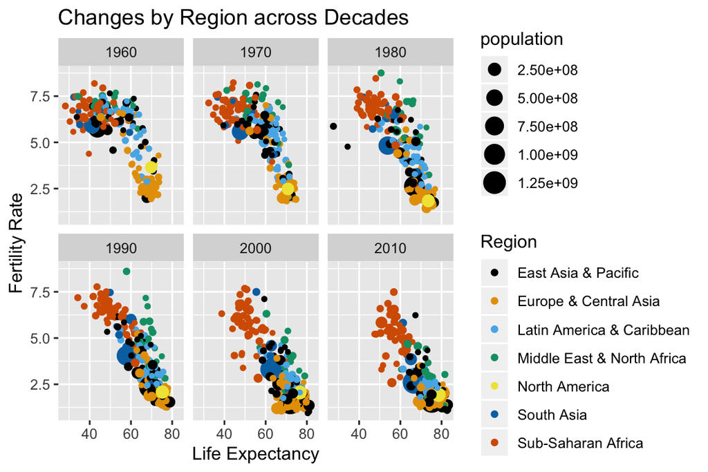

```r
ggplot(data = country_loan1)+
  geom_point(mapping = aes(x = life_exp, y = fertility, color = Region, size = population))+
  facet_wrap(~year)+
  labs(x = "Life Expectancy", y = "Fertility Rate", title = "Changes by Region across Decades")+
  scale_colour_colorblind()
```

```r
# From the plot we can see the with the increase of the life expectancy, the fertility rate will decrease.
```

5. Calculate the total population for each region for each year.
- Exclude 2018.
- Make a line plot of year versus log of total population, color-coding by region.
- Your final plot should look like this:
- **Interpret the plot in one sentence**.

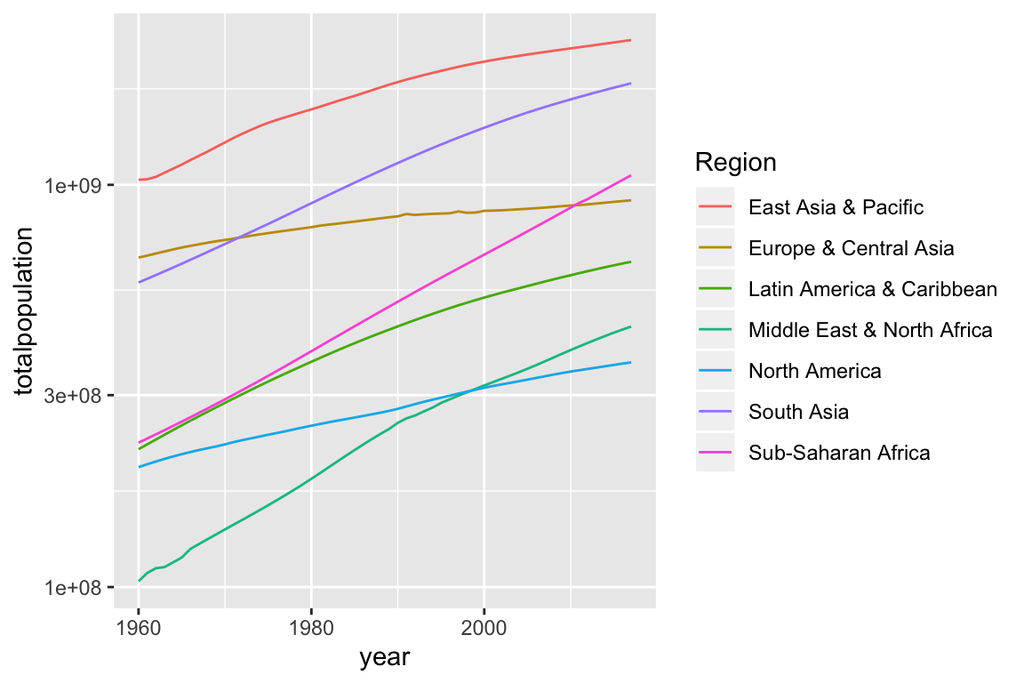

```r
RegionPopulation <- country_loan %>%
  group_by(Region, year) %>%
  summarise(totalpopulation = sum(population))
ggplot(data = RegionPopulation) +
  geom_line(mapping = aes(x = year, y = totalpopulation, group = Region, color = Region))+
  scale_y_log10()
```

```r
# From the plot we can see there are more and more populationfrom 1960 to 2017.
```

6. Make a bar plot of population vs region for the year 2017.
- Order the bars on the $y$-axis in **decreasing** order of population.
- Your final plot should look like this:

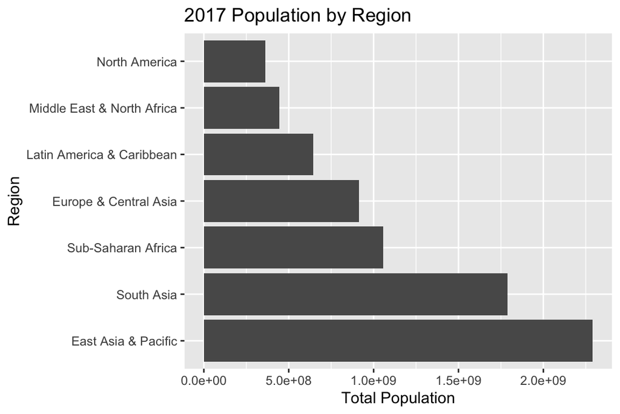

```r
population2017 <- RegionPopulation %>%
  filter(year == 2017)
ggplot(data = population2017) +
  geom_bar(mapping = aes(x = reorder(Region, -totalpopulation), y = totalpopulation), stat = "identity")+
  coord_flip()+
  labs(x = "Region", y = "Total Population", title = "2017 Population by Region")
```